# 572_HW_2

Matthew Stoebe

2024-10-05

#Chapter 3 Question 5 An agronomist gave scores fro 0 to 5 to denote insect damage to wheat plants that were treated with four insecticides. The data are given in the following table. Use the Kruskal-Wallis test with ties to test whether or not there is a difference among the treatments

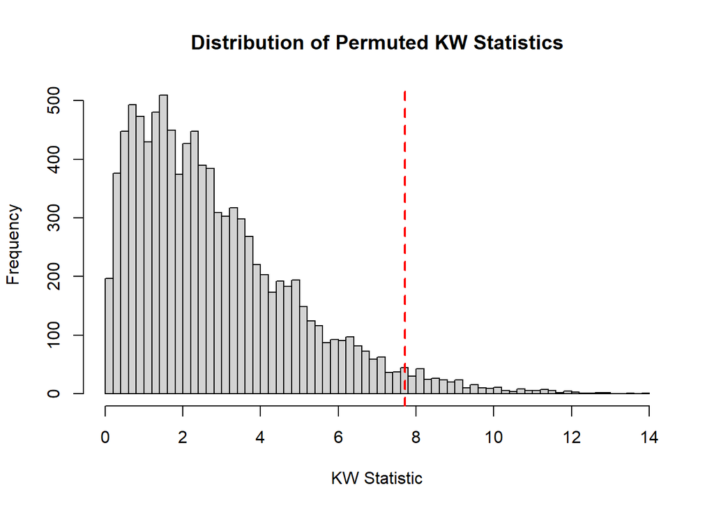

```r
t1 <- c(0,2,1,3,1,1)
t2 <- c(2,1,3,1,3,4)
t3 <- c(1,3,4,2,2,1)
t4 <- c(3,4,2,5,3,4)

all_data <- c(t1, t2, t3, t4)

N <- length(all_data)

ranks <- rank(all_data, ties.method = "average")

n <- length(t1)  # since all groups have the same size, you can use any group's length

# Split the ranks back into their respective groups
ranked_group_1 <- ranks[1:n]
ranked_group_2 <- ranks[(n+1):(2*n)]
ranked_group_3 <- ranks[(2*n+1):(3*n)]
ranked_group_4 <- ranks[(3*n+1):(4*n)]

KW_obs <-
  (12 / (N * (N + 1))) * sum(
    n * (mean(ranked_group_1) - (N + 1) / 2)^2,
    n * (mean(ranked_group_2) - (N + 1) / 2)^2,
    n * (mean(ranked_group_3) - (N + 1) / 2)^2,
    n * (mean(ranked_group_4) - (N + 1) / 2)^2
  )

KW_obs <-
  (12 / (N * (N + 1))) * sum(
    n * (mean(ranked_group_1) - (N + 1) / 2)^2,
    n * (mean(ranked_group_2) - (N + 1) / 2)^2,
    n * (mean(ranked_group_3) - (N + 1) / 2)^2,
    n * (mean(ranked_group_4) - (N + 1) / 2)^2
  )

KW_stats <- numeric(10000)

for (k in 1:10000) {
  permuted_ranks <- sample(ranks)

  perm_ranked_group_1 <- permuted_ranks[1:n]
  perm_ranked_group_2 <- permuted_ranks[(n+1):(2*n)]
  perm_ranked_group_3 <- permuted_ranks[(2*n+1):(3*n)]
  perm_ranked_group_4 <- permuted_ranks[(3*n+1):(4*n)]

  KW_perm <-
    (12 / (N * (N + 1))) * sum(
      n * (mean(perm_ranked_group_1) - (N + 1) / 2)^2,
      n * (mean(perm_ranked_group_2) - (N + 1) / 2)^2,
      n * (mean(perm_ranked_group_3) - (N + 1) / 2)^2,
      n * (mean(perm_ranked_group_4) - (N + 1) / 2)^2
    )

  KW_stats[k] <- KW_perm
}


# Plot the histogram of permuted Kruskal-Wallis statistics
hist(KW_stats, main = "Distribution of Permuted KW Statistics", xlab = "KW Statistic", breaks = 50)
abline(v = KW_obs, col = "red", lwd = 2, lty = 2)
```

```r
percentage_greater <- mean(KW_stats >= KW_obs)

print(paste("Observed Kruskal-Wallis statistic:", round(KW_obs,2)))
```

```
## [1] "Observed Kruskal-Wallis statistic: 7.71"
```

```r
print(paste("Percentage of permuted statistics greater than observed:", percentage_greater * 100, "%"))
```

```
## [1] "Percentage of permuted statistics greater than observed: 3.25 %"
```

#Chapter 4 Question 4 Measurements of the blood enzyme LDH were taken on seven subjects before fasting and after fasting. Is there a significant difference between the LDH readings before and after fasting? Test using Wilcox’s signed-rank statistic. Compare the p-value of the exact test with that of the normal approximation.

```r
t1 <- c(89,90,87,98,120,85,97)
t2 <- c(76,101,84,86,105,84,93)

obs_diff_ranks <- rank(c(t2 - t1), ties.method="average")
obs_diff_signs <- sign(c(t2 - t1))

obs_signed_ranks <- obs_diff_ranks * obs_diff_signs
obs_sum_pos_ranks <- sum(obs_signed_ranks[obs_signed_ranks > 0])

cat("Observed sum of positive ranks:", obs_sum_pos_ranks, "\n")
```

```
## Observed sum of positive ranks: 7
```

```r
n_perm <- 10000
perm_stats <- numeric(n_perm)

for (k in 1:n_perm){
  flip <- sample(c(1, -1), size = length(t1), replace = TRUE)
  signed_ranks <- rank(c(t2 - t1), ties.method="average") * flip
  perm_stats[k] <- sum(signed_ranks[signed_ranks > 0])
}

# Calculate p-value
p_value <- mean(perm_stats >= obs_sum_pos_ranks) * 100

cat("Percentage of Permutations with a more extreme difference than observed:", p_value, "%\n")
```

```
## Percentage of Permutations with a more extreme difference than observed: 89.34 %
```

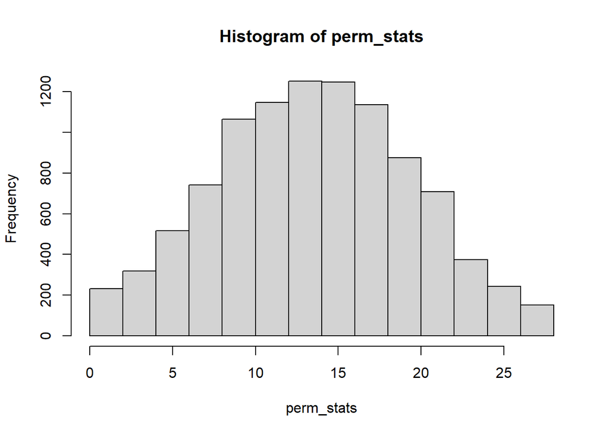

```r
hist(perm_stats)
```

```r
n = length(t1)

exp_sr = (n * (n+1))/4
var_sr = (n * (n+1) * (2*n + 1))/24

Z = (obs_sum_pos_ranks - exp_sr)/sqrt(var_sr)

pnorm(q=Z, lower.tail=FALSE)
```

```
## [1] 0.8816382
```

#Chapter 5 Question 3 The data in the table are the ages in days of concrete cylinders and the compression strengths of the cylinders. a. Plot the data to show a nonlinear relationship. Compute Pearsons, Spearmans and Kendall’s Tau b. Test for significant association using each of the measures of association in part a

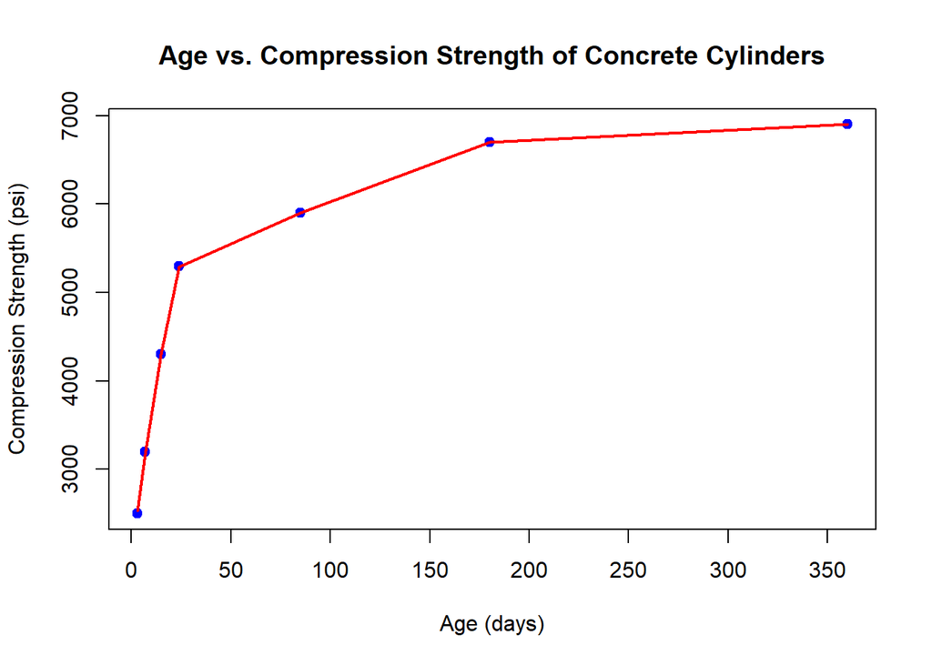

```r
Age <- c(3,7,15,24,85,180,360)
Strength <- c(2500,3200,4300,5300,5900,6700,6900)

plot(Age, Strength,
     main = "Age vs. Compression Strength of Concrete Cylinders",
     xlab = "Age (days)",
     ylab = "Compression Strength (psi)",
     pch = 19,        # Solid circle
     col = "blue")    # Color of the points

lines(smooth.spline(Age, Strength), col = "red", lwd = 2)
```

```r
cat("Automatic calculations")
```

```
## Automatic calculations
```

```r
pearson_cor <- cor(Age, Strength, method = "pearson")
print(paste("Pearson's r:", round(pearson_cor, 4)))
```

```
## [1] "Pearson's r: 0.7858"
```

```r
# Spearman's Rank Correlation
spearman_cor <- cor(Age, Strength, method = "spearman")
print(paste("Spearman's rho:", round(spearman_cor, 4)))
```

```
## [1] "Spearman's rho: 1"
```

```r
# Kendall's Tau
kendall_cor <- cor(Age, Strength, method = "kendall")
print(paste("Kendall's Tau:", round(kendall_cor, 4)))
```

```
## [1] "Kendall's Tau: 1"
```

```r
print("Manual calculations")
```

```
## [1] "Manual calculations"
```

```r
n<- length(Age)

mean_Age <- sum(Age) / n
mean_Strength <- sum(Strength) / n

dev_Age <- Age - mean_Age
dev_Strength <- Strength - mean_Strength

numerator <- sum(dev_Age * dev_Strength)

denominator <- sqrt(sum(dev_Age^2) * sum(dev_Strength^2))

pearson_r <- numerator / denominator

cat("Manual Calculation of Pearson's r:", round(pearson_r, 4), "\n")
```

```
## Manual Calculation of Pearson's r: 0.7858
```

```r
rank_Age <- rank(Age, ties.method = "average")
rank_Strength <- rank(Strength, ties.method = "average")

d <- rank_Age - rank_Strength

d_squared <- d^2

sum_d_squared <- sum(d_squared)

spearman_rho <- 1 - (6 * sum_d_squared) / (n * (n^2 - 1))

cat("Manual Calculation of Spearman's rho:", round(spearman_rho, 4), "\n")
```

```
## Manual Calculation of Spearman's rho: 1
```

```r
calculate_kendall_tau <- function(x, y) {
  C <- 0  # Concordant pairs
  D <- 0  # Discordant pairs
  n <- length(x)

  for(i in 1:(n-1)) {
    for(j in (i+1):n) {
      # Compare pairs
      if((x[i] < x[j] && y[i] < y[j]) || (x[i] > x[j] && y[i] > y[j])) {
        C <- C + 1
      } else if((x[i] < x[j] && y[i] > y[j]) || (x[i] > x[j] && y[i] < y[j])) {
        D <- D + 1
      }
      # Ties are not considered in this basic implementation
    }
  }

  tau <- (C - D) / (0.5 * n * (n - 1))
  return(tau)
}

# Calculate Kendall's Tau
kendall_tau <- calculate_kendall_tau(Age, Strength)

# Display the result
cat("Manual Calculation of Kendall's Tau:", round(kendall_tau, 4), "\n")
```

```
## Manual Calculation of Kendall's Tau: 1
```